# Algumas Observações Sobre Filmes da Pixar

Jonatan, Kallin, Wagner, Vitor

23 novembro, 2022

# 1 Contextualização

O banco de dados que escolhemos analisar faz parte de um pacote chamado “dados”, se trata de um pacote que traduz bases de dados famosas de outros pacotes. E a database que analisamos, traz os números referentes a bilheteria e outras informações à respeito de alguns filmes da pixar.

# 2 Carregamento de pacotes

Os pacotes que utilizamos foram:

```r
library(tidyverse)
library(kableExtra)
library(dados)
```

# 3 Leitura e visualização do banco de dados

As base que utilizamos contam com um total de 24 obsevações e 9 variáveis, sendo elas:

1. `filme`: Nome do filme analisado;
2. `orcamento`: Orçamento que o filme recebeu para sua produção em milhões de dólares;
3. `bilheteria_eua_canada`: Valor arrecadado com as bilheterias dos Estados Unidos e do Canadá em milhões de dólares;
4. `bilheteria_outros_paises`: Valor arrecadado com as bilheterias dos demais países em milhões;
5. `bilheteria_mundial`: Bilheteria total arrecadada em milhões de dólares;
6. `nota_rotten_tomatoes`: Nota crítica do filme pelo site [Rotten Tomatoes](https://www.rottentomatoes.com/) de 0 (ruim) à 100 (bom);
7. `nota_metacritic`: Nota crítica do filme pelo site [Metacritic](https://www.metacritic.com/) de 0 (ruim) à 100 (bom);
8. `nota_cinema_score`: Nota crítica do filme pelo site [Cinema Score](https://www.cinemascore.com/) sendo avaliado de -A (ruim) à A++ (bom);
9. `nota_critics_choice`: Nota crítica pelo site [Critics Choice](https://www.criticschoice.com/) de 0 (ruim) à 100 (bom).

```r
dados1 <- pixar_bilheteria
dados1[c("orcamento", "bilheteria_eua_canada", "bilheteria_outros_paises",
         "bilheteria_mundial")] <- dados1[c("orcamento", "bilheteria_eua_canada", "bilheteria_outros_paises","bilheteria_mundial")]/1e6
renomeando_colunas <- c(
  "Filmes", "Orçamento", "Bilheteria EUA/CA", "Bilheteria de outros países",
  "Bilheteria mundial"
)
colnames(dados1) <- renomeando_colunas
glimpse(dados1)
```

```
## Rows: 24
## Columns: 5
## $ Filmes                        <chr> "Toy Story - Um Mundo de Aventuras", "Vi…
## $ Orçamento                     <dbl> 30, 120, 90, 115, 94, 92, 120, 150, 180,…
## $ `Bilheteria EUA/CA`           <dbl> 191.79623, 162.79856, 245.85218, 289.916…
## $ `Bilheteria de outros países` <dbl> 181.75780, 200.46029, 251.52260, 342.400…
## $ `Bilheteria mundial`          <dbl> 373.5540, 363.2589, 497.3748, 632.3166, …
```

## 3.1 Coluna com 10 filmes

Alguns filmes que foram analisados:

```r
kable(head(dados1, 10), col.names = c("Filmes", "Orçamentos (em milhões)", "Bilheteria EUA/CA (em milhões)", "Bilheteria de outros países (em milhões)", "Bilheteria mundial (em milhões)"))|>
  kable_styling(full_width = F, bootstrap_options = c("striped", "hover", "condensed", "responsive"))
```

| Filmes | Orçamentos (em milhões) | Bilheteria EUA/CA (em milhões) | Bilheteria de outros países (em milhões) | Bilheteria mundial (em milhões) |
| --- | --- | --- | --- | --- |
| Toy Story - Um Mundo de Aventuras | 30 | 191.7962 | 181.7578 | 373.5540 |
| Vida de Inseto | 120 | 162.7986 | 200.4603 | 363.2589 |
| Toy Story 2 | 90 | 245.8522 | 251.5226 | 497.3748 |
| Monstros S. A. | 115 | 289.9163 | 342.4004 | 632.3166 |
| Procurando Nemo | 94 | 339.7150 | 531.3000 | 871.0150 |
| Os Incríveis | 92 | 261.4411 | 370.1656 | 631.6067 |
| Carros | 120 | 244.0830 | 217.9002 | 461.9831 |
| Ratatouille | 150 | 206.4457 | 417.2804 | 623.7261 |
| WALL-E | 180 | 223.8082 | 297.5037 | 521.3119 |
| Up - Altas Aventuras | 175 | 293.0042 | 442.0949 | 735.0991 |

# 4 Gráficos

## 4.1 Orçamento por filme

Nesse gráfico podemos observar quais filmes tiveram melhor orçamento para sua produção

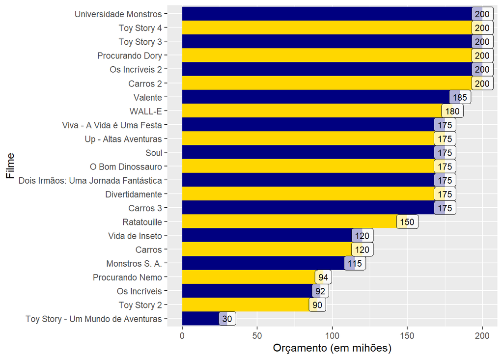

```r
dados <- pixar_bilheteria
dados[c("orcamento", "bilheteria_eua_canada", "bilheteria_outros_paises",
         "bilheteria_mundial")] <- dados[c("orcamento", "bilheteria_eua_canada", "bilheteria_outros_paises","bilheteria_mundial")]/1e6
dados1 <- slice(dados, -24)
ggplot(dados1, aes(x = reorder(filme, orcamento), y = orcamento, fill = filme, label = orcamento))+
  geom_col(stat = "identity", width = 1.0)+
  coord_flip()+
  scale_fill_manual(values = c("WALL-E" = "gold",
                               "Viva - A Vida é Uma Festa" = "navy",
                    "Vida de Inseto" = "navy",
                    "Valente" = "navy",
                    "Up - Altas Aventuras" = "gold",
                    "Universidade Monstros" = "navy",
                    "Toy Story 4" = "gold",
                    "Toy Story 3" = "navy",
                    "Toy Story 2" = "gold",
                     "Toy Story - Um Mundo de Aventuras" = "navy",
                    "Soul" = "navy",
                    "Ratatouille" = "gold",
                    "Procurando Nemo" = "gold",
                    "Procurando Dory" = "gold",
                    "Os Incríveis 2" = "navy",
                    "Os Incríveis" = "navy",
                    "O Bom Dinossauro" = "gold",
                    "Monstros S. A." = "navy",
                    "Dois Irmãos: Uma Jornada Fantástica" = "navy",
                    "Divertidamente" = "gold",
                    "Carros 3" = "navy",
                    "Carros 2" = "gold",
                    "Carros" = "gold"
                     ))+
  theme_replace()+
  theme(legend.position="none")+
  geom_label(fill = "white", alpha = 0.7, size = 3.0)+
  scale_y_continuous(expand = expansion(add = c(0,0)))+
ggplot2::scale_y_continuous()+
  labs(y = "Orçamento (em mihões)", x = "Filme")
```

## 4.2 Comparando as Bilheterias

Neste gráfico comparamos a bilheteria arrecadada nos Estados Unidos e Canadá com o restante do mundo. Podemos observar que os dois países lideram o consumo de filmes e representam juntos quase metade de todo o valor arrecadado mundialmente.

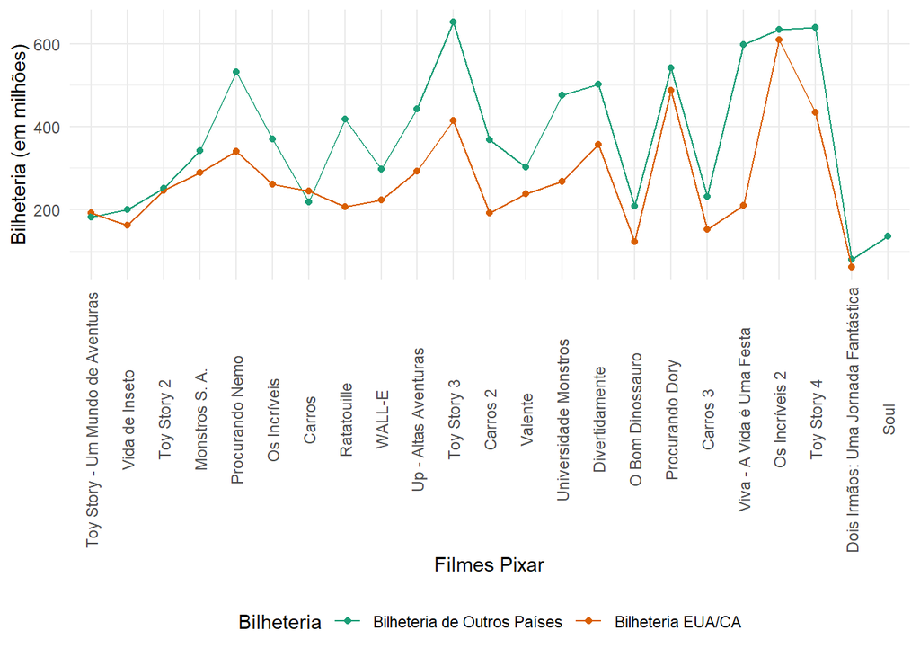

```r
dados <- pixar_bilheteria
dados[c("orcamento", "bilheteria_eua_canada", "bilheteria_outros_paises",
         "bilheteria_mundial")] <- dados[c("orcamento", "bilheteria_eua_canada", "bilheteria_outros_paises","bilheteria_mundial")]/1e6
dados2 <- dados |>
  select (-orcamento, -bilheteria_mundial) |>
  mutate(filme = fct_inorder(filme)) |>
  pivot_longer(cols = c("bilheteria_eua_canada", "bilheteria_outros_paises"),
               names_to = "bilheteria",
               values_to = "valor") |>
  mutate(bilheteria = case_when(
    bilheteria == "bilheteria_eua_canada" ~ "Bilheteria EUA/CA",
    bilheteria == "bilheteria_outros_paises" ~ "Bilheteria de Outros Países"
  )) |>
  drop_na()
dados2 |>
  ggplot(aes(x = filme, y = valor, col = bilheteria)) +
  geom_point() +
  geom_line(aes(group = bilheteria)) +
  scale_color_brewer(palette = "Dark2") +
  labs(x = "Filmes Pixar", y = "Bilheteria (em milhões)") +
  guides(col = guide_legend(title = "Bilheteria")) +
  theme_minimal() +
  theme(axis.text.x = element_text(angle = 90, vjust = 0.5),
        legend.position = "bottom")
```

## 4.3 Comparando Avaliações com as Bilheterias

Aqui podemos observar que a bilheteria dos filmes pode ser correlacionada com o valor orçamentário que o filme teve para ser produzido porém, a nota, mesmo com observações consideráveis, não tem resultados conclusivos a respeito da sua correlação com a bilheteria.

[figure not shown]

```r
dados3 <- pixar_avalicao_publico
dados4 <- merge.data.frame(dados, dados3)
ggplot(dados4, aes(x = bilheteria_mundial, y = nota_rotten_tomatoes,
                   color = orcamento))+
  geom_point(size = 5.0)+
  scale_color_gradient(low = "blue", high = "red")+
  stat_smooth(method = "lm", col = "red")+
  labs(x = "Bilheteria Mundial (em milhões)", y = "Rotten Tomatoes")
```

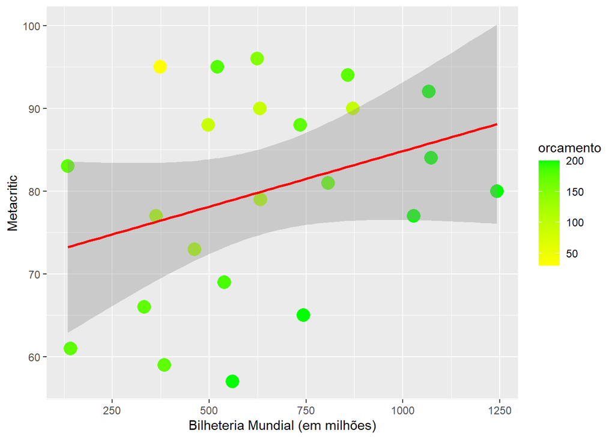

```r
dados4 <- merge.data.frame(dados, dados3)
ggplot(dados4, aes(x = bilheteria_mundial, y = nota_metacritic,
                   color = orcamento))+
  geom_point(size = 5.0)+
  scale_color_gradient(low = "yellow", high = "green")+
  stat_smooth(method = "lm", col = "red")+
  labs(x = "Bilheteria Mundial (em milhões)", y = "Metacritic")
```

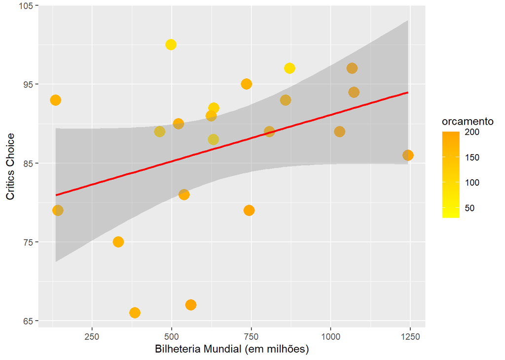

```r
dados4 <- merge.data.frame(dados, dados3)
ggplot(dados4, aes(x = bilheteria_mundial, y = nota_critics_choice,
                   color = orcamento))+
  geom_point(size = 5.0)+
  scale_color_gradient(low = "yellow", high = "orange")+
  stat_smooth(method = "lm", col = "red")+
  labs(x = "Bilheteria Mundial (em milhões)", y = "Critics Choice")
```